# Prophet vs BSTS

## Introduction & purpose

[Prophet](https://facebook.github.io/prophet/) is a forecasting procedure and R package developed by Facebook that I have used professionally and have seen colleagues using it pretty sucessfully in diverse setups.

In this post, I run a kind of benchmark with just one scenario: the [MineThatData Forecasting Challenge](https://blog.minethatdata.com/2017/09/the-minethatdata-forecasting-challenge.html) that the authors of this blog actually won using [BSTS](http://sisifospage.tech/2017-10-30-forecasting-bsts.html).

`BSTS` and `prophet` are certainly different techniques (even if they have quite some in common). Anyhow this is not the point of this post; rather, since `prophet` is quite straight forward to use, the main question that comes to mind is actually, can a model be fit with `prophet` in a simpler way than with `BSTS` obtaining comparable results? Certainly, my guess is that `BSTS` as used for the challenge was far from simple for the readers of [MineThatData](https://blog.minethatdata.com).

## Fit directly and see how lucky we get

Let’s go straight like a crazy gunman and try to fit a model with `prophet` with a lot of defaults and see what happens.

```r
library(lubridate)
library(prophet)
library(readxl)
library(httr)

GET("http://minethatdata.com/MineThatData_ForecastChallenge_20170914.xlsx",
    write_disk(tf <- tempfile(fileext = ".xlsx")))
```

```
## Response [http://minethatdata.com/MineThatData_ForecastChallenge_20170914.xlsx]
##   Date: 2020-12-09 08:13
##   Status: 200
##   Content-Type: application/vnd.openxmlformats-officedocument.spreadsheetml.sheet
##   Size: 21.8 kB
## <ON DISK>  /var/folders/lm/6kvyzp5d3ds_20dxw939n5hw0000gp/T//RtmphKlisw/file585b45bf51fa.xlsx
```

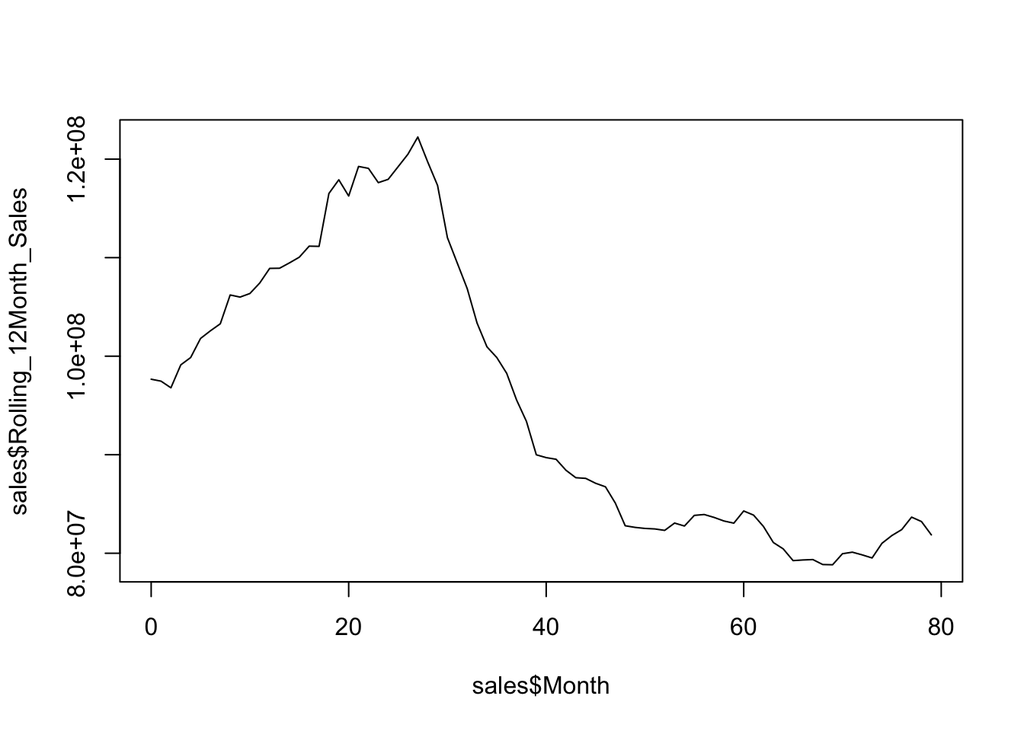

```r
sales <-
  read_excel(tf, sheet=1,
             col_names=TRUE, col_types=rep("numeric", 17))
sales <- sales[! duplicated(sales$Month),]
plot(sales$Month, sales$Rolling_12Month_Sales, type="l")
```

Let’s prepare the data a bit more for `prophet`; the package needs a time series with dates, in this case for monthly data.

```r
target <- sales[order(sales$Month),]
end_date <- as.Date("2017-08-01")
initial_date <- end_date %m-% months(79)

target$date <- seq(initial_date, end_date, by="1 month")

sales4prophet <- target[, c("date", "Rolling_12Month_Sales")]
names(sales4prophet) <- c("ds", "y")
head(sales4prophet)
```

| ds | y |
| --- | --- |
| 2011-01-01 | 97662797 |
| 2011-02-01 | 97465558 |
| 2011-03-01 | 96791002 |
| 2011-04-01 | 99119213 |
| 2011-05-01 | 99863883 |
| 2011-06-01 | 101798253 |

```r
m <- prophet(weekly.seasonality=FALSE)
m <- add_seasonality(m, name='yearly', period=365, fourier.order=5)
m <- fit.prophet(m, sales4prophet)

future <- make_future_dataframe(m, 3, 'month')
forecast <- predict(m, future)
```

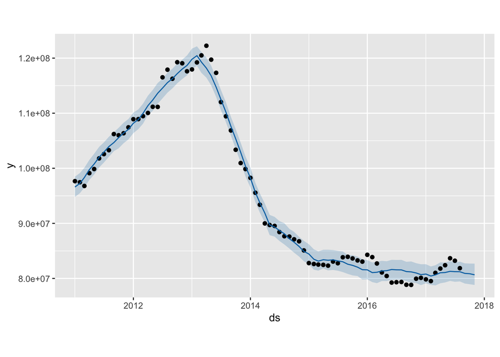

```r
plot(m, forecast)
```

The last predictions are,

```r
tail(forecast[, c('ds', 'yhat')])
```

|  | ds | yhat |
| --- | --- | --- |
| 78 | 2017-06-01 | 81290751 |
| 79 | 2017-07-01 | 81234425 |
| 80 | 2017-08-01 | 81220893 |
| 81 | 2017-09-01 | 80918719 |
| 82 | 2017-10-01 | 80859139 |
| 83 | 2017-11-01 | 80661314 |

If you measure it with the criteria of the [MineThatData Forecasting Challenge](https://blog.minethatdata.com/2017/11/the-minethatdata-forecasting-challenge_14.html), let’s calculate squared error of this solution,

```r
formatC(sum((c(81.8e6, 81.3e6, 80.5e6) - tail(forecast, 3)["yhat"]) **2), format="e")
```

```
## [1] "9.9704e+11"
```

Thus about 1 trillion, which would not win the challenge, but it is not too bad, it would have been the 3rd solution (`BSTS` won with 0.4)… There is certainly one good thing about it: the model makes it right when predicting that the sales will continue going down. It simplifies reality a bit too much, disregarding the last 2 bumps in June 2017 and January 2016, but it makes a reasonible prediction with little effort.

Another good point about the prediction is that maybe is not the best, but it is prety *interesting*: makes a very good job for the 3rd month of the prediction, it would be actually better than any of the solutions proposed in the challenge in that regard.

In the following plot, the trend vs seasonaility components of the prediction are shown

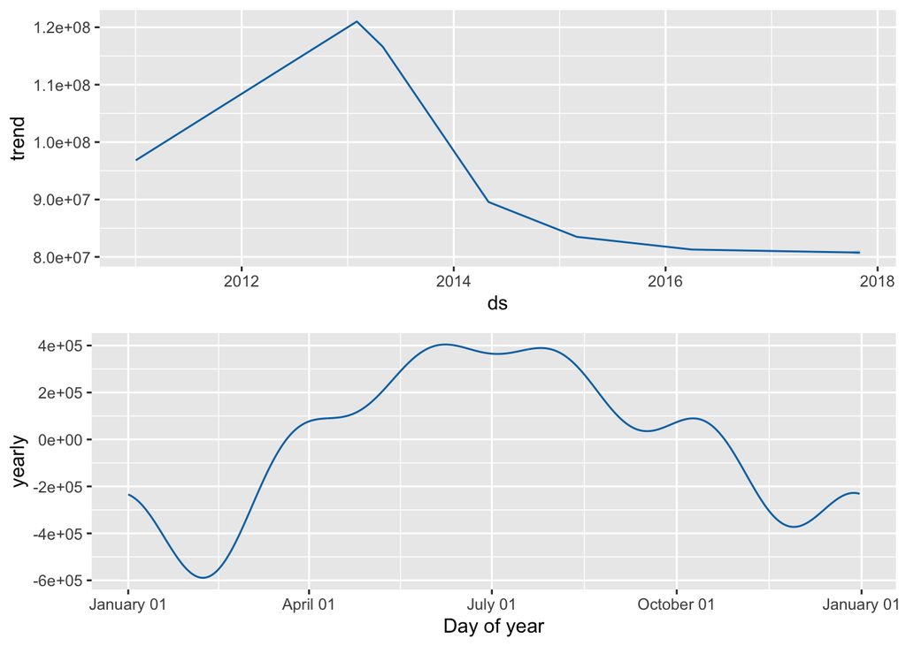

```r
prophet_plot_components(m, forecast)
```

## Now with cross-validation?

Actually the post could end in the last paragraphs. Mission accomplished: `prophet` certainly provides a very decent prediction with little effort. But inevitable one feels tempted to answer another question: can we beat `BSTS` in this case?

```r
m2 <- prophet(weekly.seasonality=FALSE, changepoint.prior.scale=0.05, seasonality.prior.scale=1.0)
m2 <- add_seasonality(m2, name='yearly', period=365, fourier.order=3)
m2 <- fit.prophet(m2, sales4prophet)

future2 <- make_future_dataframe(m2, 3, 'month')
forecast2 <- predict(m2, future2)
```

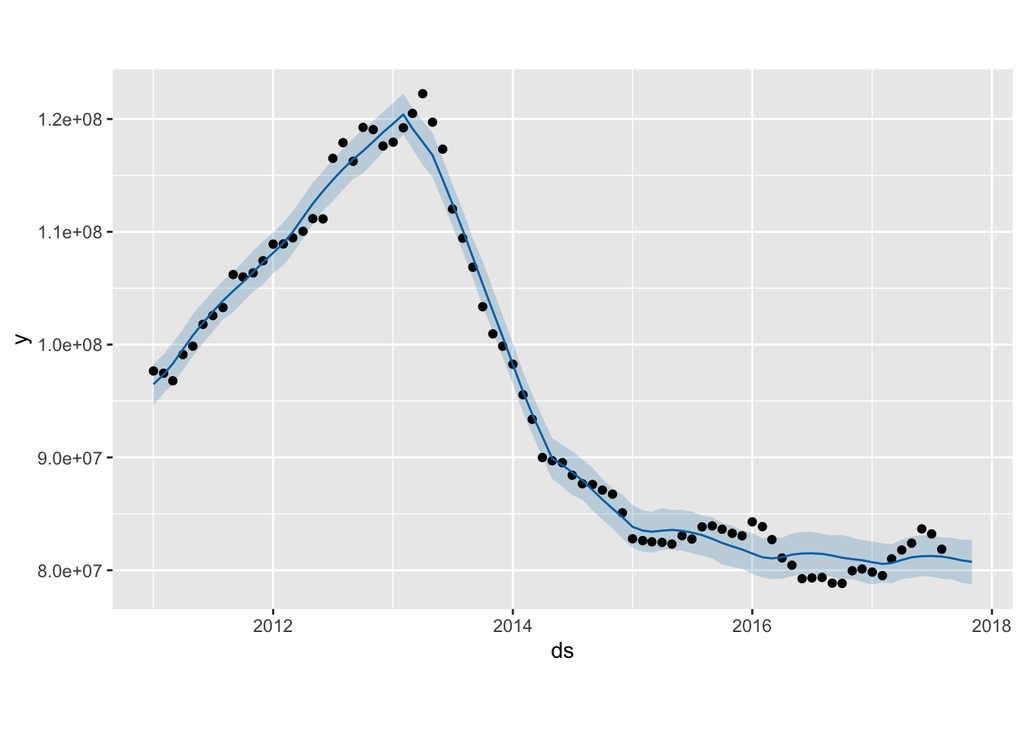

```r
plot(m2, forecast2)
```

The plot looks actually pretty closed to the madman model with defaults above. These are the last datapoints,

```r
tail(forecast2[, c('ds', 'yhat')])
```

|  | ds | yhat |
| --- | --- | --- |
| 78 | 2017-06-01 | 81245095 |
| 79 | 2017-07-01 | 81260364 |
| 80 | 2017-08-01 | 81215703 |
| 81 | 2017-09-01 | 81062220 |
| 82 | 2017-10-01 | 80873059 |
| 83 | 2017-11-01 | 80748923 |

And the squared error became about 20% better, still 3rd place in the challenge, but pretty closed to the second solution (that got 7e11 squared error).

```r
formatC(sum((c(81.8e6, 81.3e6, 80.5e6) - tail(forecast2, 3)["yhat"]) **2), format="e")
```

```
## [1] "7.8856e+11"
```

Seasonality is equally weak, and simpler since the fourier is order 3; only an increase of sales in summer is visible

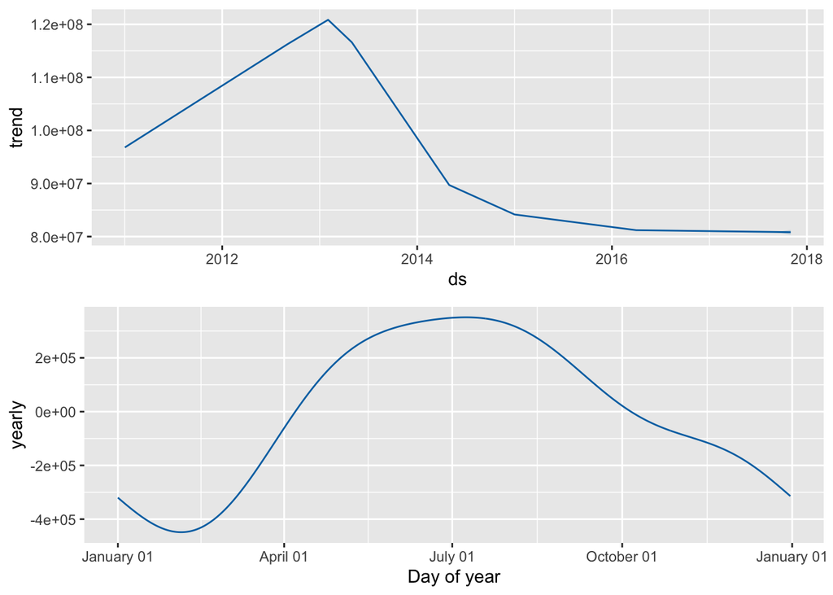

```r
prophet_plot_components(m2, forecast2)
```

So, does it worth it the effort? Well, 20% increase is not bad at all, and it wasn’t so difficult (see below). But anyway, as a baseline prediction, the 1st one would be good already.

## Conclusion

Yes, `prophet` is a pretty good package for producing baseline predicions, as they clain in [their webpage](https://facebook.github.io/prophet/): accurate and fast, automatic & tunable. Might not be the winners of a contest, but still…

## Annex: how to fit the prior hyperparameters with cross-validation

First of all, note that it quite an exercise trying not to overfit the results - when you already know the solution, inevitably you overfit, even if it is subtly and slowly. But yes, the fact that the final result is good but not so amazing maybe gives a hint that I didn’t overfit so badly…

Second, Bayesian priors are not like hyperparameters; one has a prior opinion about priors and does not look for their values in a grid -one may fine-tune a prior opinion based on business knowledge. Anyhow, in this case the target series is quite an unknown, which justifies the use of a grid.

`prophet` provides a couple of functions that make everything easy: - `cross_validation` performs forward chaining over the series - `performance_metrics` calculates over the cross validation folds above

The following is a utility encapsulating a call to both, where `model.function` is parameter function that generates the model we’d like to fit.

```r
prophet.cv.loop <- function(data_train,
                            initial,
                            period,
                            horizon,
                            units,
                            model.function) {
  model <- model.function(data_train)
  df.cv <- cross_validation(model, initial=initial, period=period, horizon=horizon, units=units)
  df.p <- performance_metrics(df.cv)
  return(df.p[nrow(df.p),]) # return last row
}
```

```r
res_df1 <- c()
for (changepoint.prior.scale in c(0.025, 0.05, 0.075, 0.1)) {
  for (fourier.order in c(3, 4, 5, 7, 9)) {
    for (seasonality.prior.scale in c(0.1, 1, 10)) {
      res <- prophet.cv.loop(
        sales4prophet,
        initial = 68*(365/12),
        period = 365/12,
        horizon = 3*365/12,
        units = "days",
        model.function = function(data_train) {
          m <- prophet(weekly.seasonality=FALSE,
                       changepoint.prior.scale=changepoint.prior.scale, seasonality.prior.scale=seasonality.prior.scale)
          m <- add_seasonality(m, name='yearly', period=365, fourier.order=fourier.order)
          m <- fit.prophet(m, sales4prophet)
          return(m)
        }
      )
      res_row <- data.frame(changepoint.prior.scale = changepoint.prior.scale,
                            fourier.order = fourier.order,
                            seasonality.prior.scale = seasonality.prior.scale)
      res_row <- cbind(res_row, res)
      print(res_row)
      res_df1 <- rbind(res_df1, res_row)
    }
  }
}
```

And these are the best solutions ordered by `mape`:

```r
head(res_df1[order(res_df1$mape, decreasing = FALSE), c('changepoint.prior.scale', 'fourier.order', 'seasonality.prior.scale', 'mape')],5)
```

|  | changepoint.prior.scale | fourier.order | seasonality.prior.scale | mape |
| --- | --- | --- | --- | --- |
| 2815 | 0.05 | 3 | 0.1 | 0.04445351 |
| 2821 | 0.05 | 5 | 0.1 | 0.04547572 |
| 2823 | 0.05 | 5 | 10.0 | 0.04634737 |
| 2819 | 0.05 | 4 | 1.0 | 0.04636393 |
| 2820 | 0.05 | 4 | 10.0 | 0.04681814 |